# Práctica 9

Lucas Fehlau Arbulu

12-05-2022

# 1 Análisis estadístico

## 1.1 Análisis preliminar

```r
hatco <- read.csv("./inputfiles/hatco2.csv", stringsAsFactors = TRUE)
```

[output not shown]

Primeros elementos de la tabla

| empresa | tamano | adquisic | tindustr | tsitcomp | velocidad | precio | flexprec | imgfabri | servconj | imgfvent | calidadp | fidelidad | nfidelidad | nsatisfac |
| --- | --- | --- | --- | --- | --- | --- | --- | --- | --- | --- | --- | --- | --- | --- |
| 1 | pequeña | descentralizada | clase A | nueva tarea | 4.1 | 0.6 | 6.9 | 4.7 | 2.4 | 2.3 | 5.2 | 32 | medio | bajo |
| 2 | grande | centralizada | otras industrias | nueva tarea | 1.8 | 3.0 | 6.3 | 6.6 | 2.5 | 4.0 | 8.4 | 43 | medio | bajo |
| 3 | grande | centralizada | clase A | recompra modificada | 3.4 | 5.2 | 5.7 | 6.0 | 4.3 | 2.7 | 8.2 | 48 | medio | alto |
| 4 | grande | centralizada | clase A | nueva tarea | 2.7 | 1.0 | 7.1 | 5.9 | 1.8 | 2.3 | 7.8 | 32 | medio | bajo |
| 5 | pequeña | descentralizada | clase A | recompra directa | 6.0 | 0.9 | 9.6 | 7.8 | 3.4 | 4.6 | 4.5 | 58 | alto | alto |
| 6 | grande | centralizada | clase A | recompra modificada | 1.9 | 3.3 | 7.9 | 4.8 | 2.6 | 1.9 | 9.7 | 45 | medio | bajo |

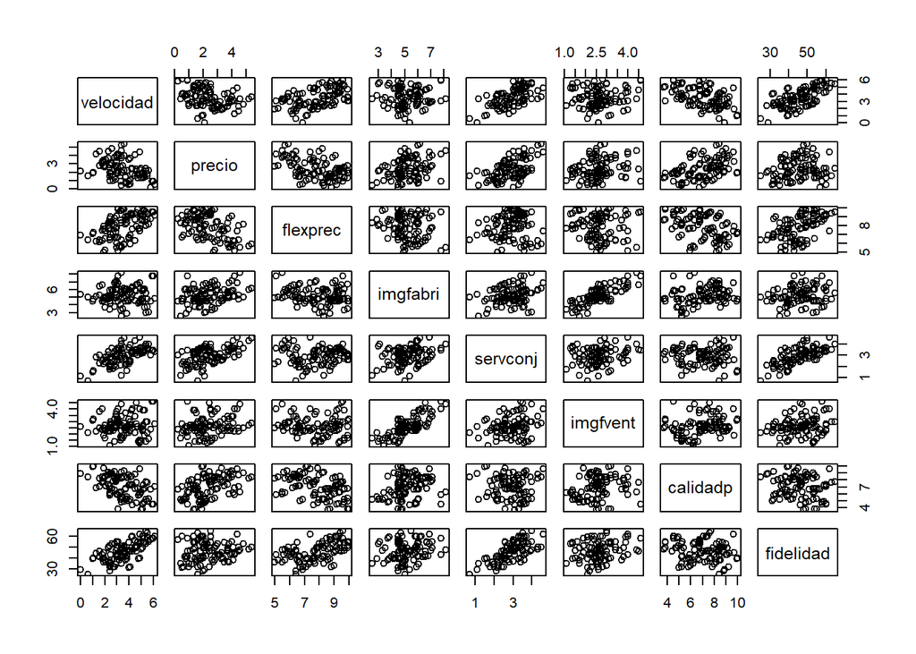

## 1.2 Primera aproximación: Relación lineal

Nos preguntamos sobre la relación lineal entre variables explicativas y explicadas. En algunas variables es significativa

En cuanto a colinealidad, parece significativa entre fidelidad y velocidad, entre velocidad y servconj, y entre servconj y fidelidad (relación lineal entre los tres)

```r
mod1 <- lm(fidelidad ~ velocidad + precio + flexprec + imgfabri + servconj + imgfvent + calidadp, hatco)
mod1
```

```
##
## Call:
## lm(formula = fidelidad ~ velocidad + precio + flexprec + imgfabri +
##     servconj + imgfvent + calidadp, data = hatco)
##
## Coefficients:
## (Intercept)    velocidad       precio     flexprec     imgfabri     servconj
##   -10.16148     -0.04352     -0.67891      3.36197     -0.04101      8.34537
##    imgfvent     calidadp
##     1.29147      0.56295
```

### 1.2.1 Inferencia sobre el modelo

```r
summary(mod1)
```

```
##
## Call:
## lm(formula = fidelidad ~ velocidad + precio + flexprec + imgfabri +
##     servconj + imgfvent + calidadp, data = hatco)
##
## Residuals:
##      Min       1Q   Median       3Q      Max
## -12.9759  -1.9491   0.5896   2.8144   6.7565
##
## Coefficients:
##              Estimate Std. Error t value Pr(>|t|)
## (Intercept) -10.16148    4.97696  -2.042   0.0440 *
## velocidad    -0.04352    2.01273  -0.022   0.9828
## precio       -0.67891    2.09025  -0.325   0.7461
## flexprec      3.36197    0.41125   8.175 1.56e-12 ***
## imgfabri     -0.04101    0.66683  -0.061   0.9511
## servconj      8.34537    3.91830   2.130   0.0359 *
## imgfvent      1.29147    0.94720   1.363   0.1761
## calidadp      0.56295    0.35544   1.584   0.1167
## ---
## Signif. codes:  0 '***' 0.001 '**' 0.01 '*' 0.05 '.' 0.1 ' ' 1
##
## Residual standard error: 4.424 on 92 degrees of freedom
## Multiple R-squared:  0.775,  Adjusted R-squared:  0.7578
## F-statistic: 45.26 on 7 and 92 DF,  p-value: < 2.2e-16
```

Observamos que $R^2 = 0.775$, $R^2 \text{ ajustado} = 0.758$

```r
anova(mod1)
```

```
## Analysis of Variance Table
##
## Response: fidelidad
##           Df Sum Sq Mean Sq  F value    Pr(>F)
## velocidad  1 3659.8  3659.8 187.0071 < 2.2e-16 ***
## precio     1  927.9   927.9  47.4128 6.932e-10 ***
## flexprec   1 1346.3  1346.3  68.7912 8.779e-13 ***
## imgfabri   1  100.4   100.4   5.1311   0.02585 *
## servconj   1   71.5    71.5   3.6517   0.05913 .
## imgfvent   1   44.9    44.9   2.2963   0.13311
## calidadp   1   49.1    49.1   2.5084   0.11667
## Residuals 92 1800.5    19.6
## ---
## Signif. codes:  0 '***' 0.001 '**' 0.01 '*' 0.05 '.' 0.1 ' ' 1
```

Varias de las variables son estadísticamente no significativas.

Hacemos una observación importante: ANOVA y el sumario del modelo dan resultados distintos en cuanto a la importancia de varias variables. Eso sugiere que estén correlacionadas (por lo cual el cambio en una ya se ve reflejada implícitamente en el resto de datos)

## 1.3 Otro modelo: factores

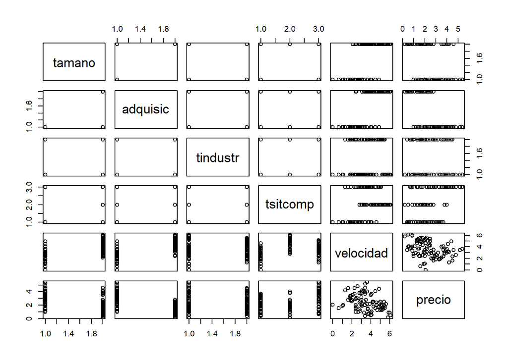

```r
plot(hatco[, c(2:7)])
```

```r
otroMod <- lm(fidelidad ~ tamano + adquisic + tindustr + tsitcomp + velocidad + precio, hatco)
otroMod
```

```
##
## Call:
## lm(formula = fidelidad ~ tamano + adquisic + tindustr + tsitcomp +
##     velocidad + precio, data = hatco)
##
## Coefficients:
##                 (Intercept)                tamanopequeña
##                     26.2895                      -4.3936
##     adquisicdescentralizada     tindustrotras industrias
##                      0.3535                       2.0003
##    tsitcomprecompra directa  tsitcomprecompra modificada
##                     15.2645                       5.9453
##                   velocidad                       precio
##                      2.8240                       1.8007
```

```r
summary(otroMod)
```

```
##
## Call:
## lm(formula = fidelidad ~ tamano + adquisic + tindustr + tsitcomp +
##     velocidad + precio, data = hatco)
##
## Residuals:
##     Min      1Q  Median      3Q     Max
## -8.6686 -2.7088  0.0551  2.7461  7.6447
##
## Coefficients:
##                             Estimate Std. Error t value Pr(>|t|)
## (Intercept)                  26.2895     2.0023  13.129  < 2e-16 ***
## tamanopequeña                -4.3936     1.5020  -2.925  0.00434 **
## adquisicdescentralizada       0.3535     2.0041   0.176  0.86039
## tindustrotras industrias      2.0003     0.8202   2.439  0.01666 *
## tsitcomprecompra directa     15.2645     1.5480   9.861 4.48e-16 ***
## tsitcomprecompra modificada   5.9453     1.3103   4.537 1.72e-05 ***
## velocidad                     2.8240     0.5036   5.608 2.13e-07 ***
## precio                        1.8007     0.5539   3.251  0.00161 **
## ---
## Signif. codes:  0 '***' 0.001 '**' 0.01 '*' 0.05 '.' 0.1 ' ' 1
##
## Residual standard error: 4.073 on 92 degrees of freedom
## Multiple R-squared:  0.8093, Adjusted R-squared:  0.7947
## F-statistic: 55.76 on 7 and 92 DF,  p-value: < 2.2e-16
```

```r
anova(otroMod)
```

```
## Analysis of Variance Table
##
## Response: fidelidad
##           Df Sum Sq Mean Sq  F value    Pr(>F)
## tamano     1 1065.9 1065.87  64.2601 3.332e-12 ***
## adquisic   1  258.5  258.54  15.5872  0.000154 ***
## tindustr   1   37.2   37.22   2.2438  0.137571
## tsitcomp   2 4451.7 2225.87 134.1952 < 2.2e-16 ***
## velocidad  1  485.6  485.64  29.2788 4.945e-07 ***
## precio     1  175.3  175.28  10.5672  0.001609 **
## Residuals 92 1526.0   16.59
## ---
## Signif. codes:  0 '***' 0.001 '**' 0.01 '*' 0.05 '.' 0.1 ' ' 1
```

El $R^2$ ronda el $80\%$ al nivel de significación $5\%$, todas las variables del mod2 son significativas salvo tindustr (con $p$-valor $0.13 > 0.05$)

## 1.4 Relevancia del término constante

Recordamos de nuevo:

```r
summary(mod1)
```

```
##
## Call:
## lm(formula = fidelidad ~ velocidad + precio + flexprec + imgfabri +
##     servconj + imgfvent + calidadp, data = hatco)
##
## Residuals:
##      Min       1Q   Median       3Q      Max
## -12.9759  -1.9491   0.5896   2.8144   6.7565
##
## Coefficients:
##              Estimate Std. Error t value Pr(>|t|)
## (Intercept) -10.16148    4.97696  -2.042   0.0440 *
## velocidad    -0.04352    2.01273  -0.022   0.9828
## precio       -0.67891    2.09025  -0.325   0.7461
## flexprec      3.36197    0.41125   8.175 1.56e-12 ***
## imgfabri     -0.04101    0.66683  -0.061   0.9511
## servconj      8.34537    3.91830   2.130   0.0359 *
## imgfvent      1.29147    0.94720   1.363   0.1761
## calidadp      0.56295    0.35544   1.584   0.1167
## ---
## Signif. codes:  0 '***' 0.001 '**' 0.01 '*' 0.05 '.' 0.1 ' ' 1
##
## Residual standard error: 4.424 on 92 degrees of freedom
## Multiple R-squared:  0.775,  Adjusted R-squared:  0.7578
## F-statistic: 45.26 on 7 and 92 DF,  p-value: < 2.2e-16
```

```r
summary(otroMod)
```

```
##
## Call:
## lm(formula = fidelidad ~ tamano + adquisic + tindustr + tsitcomp +
##     velocidad + precio, data = hatco)
##
## Residuals:
##     Min      1Q  Median      3Q     Max
## -8.6686 -2.7088  0.0551  2.7461  7.6447
##
## Coefficients:
##                             Estimate Std. Error t value Pr(>|t|)
## (Intercept)                  26.2895     2.0023  13.129  < 2e-16 ***
## tamanopequeña                -4.3936     1.5020  -2.925  0.00434 **
## adquisicdescentralizada       0.3535     2.0041   0.176  0.86039
## tindustrotras industrias      2.0003     0.8202   2.439  0.01666 *
## tsitcomprecompra directa     15.2645     1.5480   9.861 4.48e-16 ***
## tsitcomprecompra modificada   5.9453     1.3103   4.537 1.72e-05 ***
## velocidad                     2.8240     0.5036   5.608 2.13e-07 ***
## precio                        1.8007     0.5539   3.251  0.00161 **
## ---
## Signif. codes:  0 '***' 0.001 '**' 0.01 '*' 0.05 '.' 0.1 ' ' 1
##
## Residual standard error: 4.073 on 92 degrees of freedom
## Multiple R-squared:  0.8093, Adjusted R-squared:  0.7947
## F-statistic: 55.76 on 7 and 92 DF,  p-value: < 2.2e-16
```

$p$ valor $p < 10^{-16} < 0.01$, no se puede prescindir del término constante ni al Nivel de significación $5\%$ ni $1\%$ ────────────────────────────────────────────────────────────────────────────────

## 1.5 Diagnóstico del modelo

### 1.5.1 Homocedasticidad

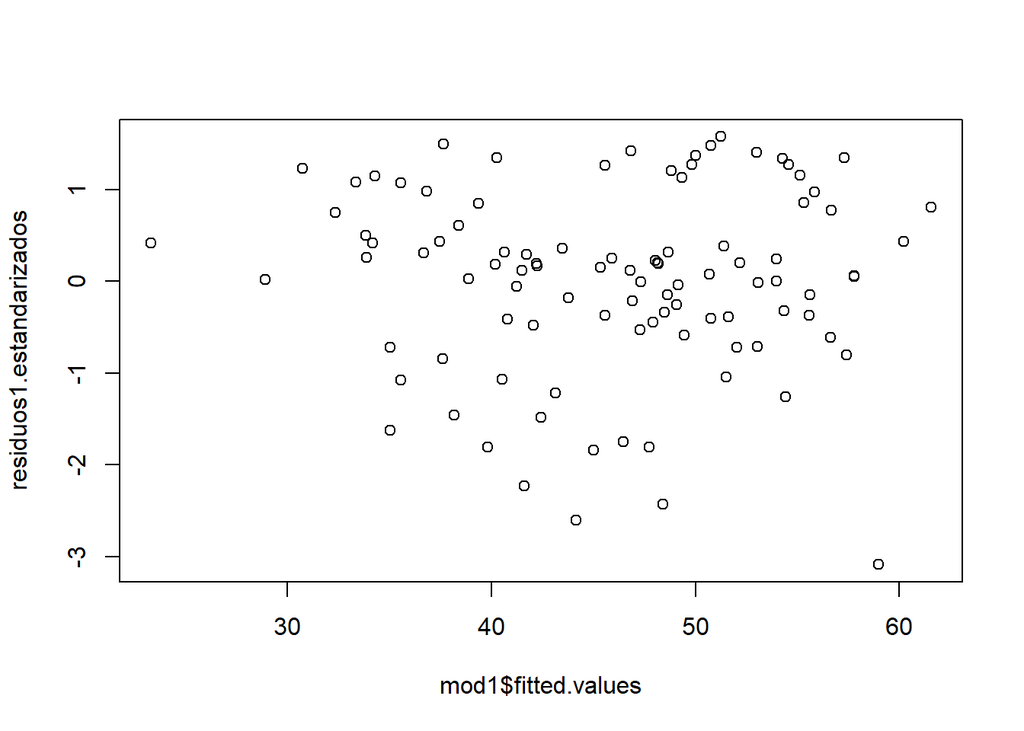

```r
residuos1.estandarizados  <- rstandard(mod1) #' residuos estandarizados
plot(mod1$fitted.values, residuos1.estandarizados)
```

```r
# plot(xij, residuos1.estandarizados) # TODO:
```

### 1.5.2 Incorrelación

```r
# plot(hatco$empresa, e)
library(lmtest)
dwtest(mod1)
```

```
##
##  Durbin-Watson test
##
## data:  mod1
## DW = 1.8924, p-value = 0.3179
## alternative hypothesis: true autocorrelation is greater than 0
```

Hipótesis nula: autocorrelación de los errores es 0. No se rechaza

### 1.5.3 Normalidad de residuos

```r
ks.test(residuos1.estandarizados, pnorm)
```

```
##
##  One-sample Kolmogorov-Smirnov test
##
## data:  residuos1.estandarizados
## D = 0.098903, p-value = 0.282
## alternative hypothesis: two-sided
```

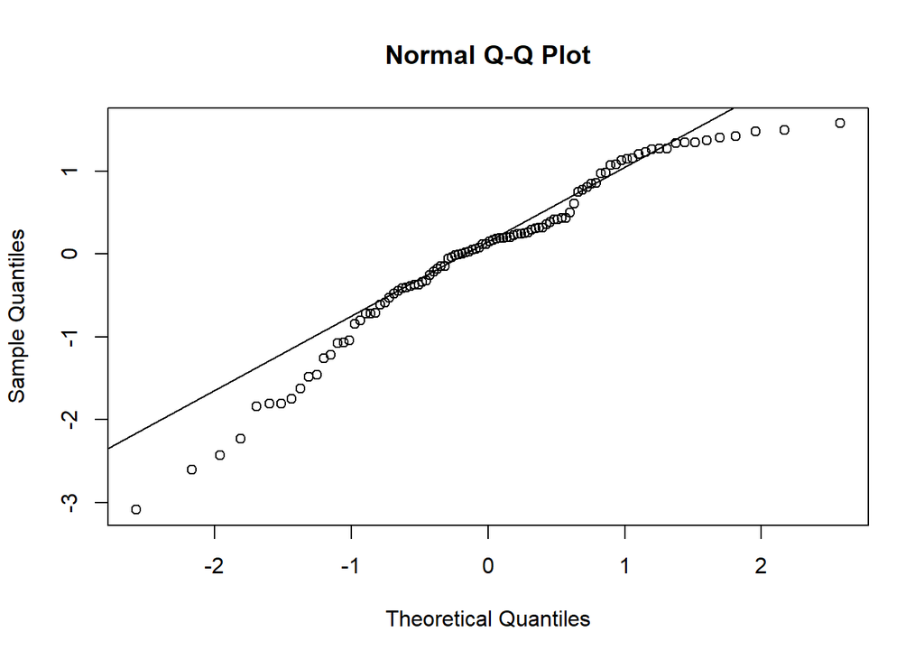

```r
qqnorm(residuos1.estandarizados)
qqline(residuos1.estandarizados)
```

### 1.5.4 Linealidad

```r
library("car")
```

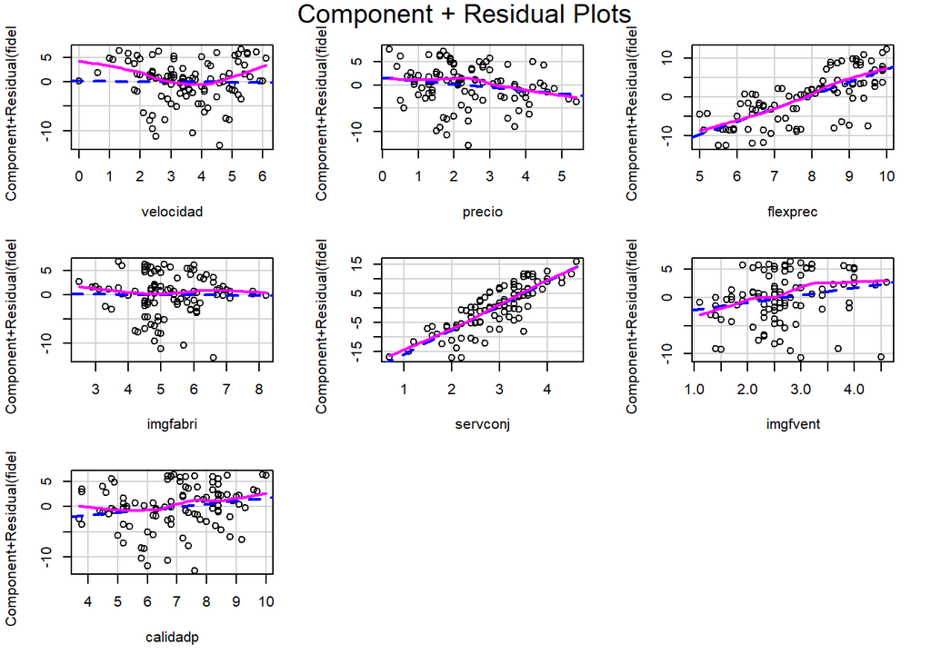

```r
crPlots(mod1)
```

La mayoría de las variables se ajustan bastante bien a la recta. Velocidad no tan bien

## 1.6 Datos anómalos

```r
sum(abs(residuos1.estandarizados) > 2.5)
```

```
## [1] 2
```

2 empresas anómalas, que son:

```r
hatco[abs(residuos1.estandarizados) > 2.5, ]
```

```
##     empresa  tamano        adquisic         tindustr    tsitcomp velocidad
## 7         7 pequeña descentralizada          clase A nueva tarea       4.6
## 100     100 pequeña descentralizada otras industrias nueva tarea       2.5
##     precio flexprec imgfabri servconj imgfvent calidadp fidelidad nfidelidad
## 7      2.4      9.5      6.6      3.5      4.5      7.6        46      medio
## 100    1.8      9.0      5.0      2.2      3.0      6.0        33       alto
##     nsatisfac
## 7        alto
## 100      bajo
```

### 1.6.1 Datos influyentes:

```r
cooks.distance(mod1) # leverage, aislamiento
```

```
##            1            2            3            4            5            6
## 2.343629e-02 7.585226e-03 7.512616e-04 5.772721e-03 6.409789e-05 1.291961e-03
##            7            8            9           10           11           12
## 1.282814e-01 2.296811e-02 1.811987e-02 8.848250e-03 3.469765e-02 6.312789e-03
##           13           14           15           16           17           18
## 4.014997e-06 4.781522e-02 2.526948e-07 3.730999e-04 1.667707e-02 2.802366e-02
##           19           20           21           22           23           24
## 6.015212e-03 8.221856e-04 1.461057e-05 4.094587e-02 2.851590e-04 9.171460e-04
##           25           26           27           28           29           30
## 1.325656e-03 9.167320e-06 1.357325e-03 3.404872e-03 6.106876e-03 1.651425e-03
##           31           32           33           34           35           36
## 4.147314e-04 2.509657e-06 8.536057e-03 8.324728e-05 6.873463e-04 8.725582e-04
##           37           38           39           40           41           42
## 1.438149e-03 2.395974e-04 3.651921e-06 1.696356e-02 1.165774e-03 5.827170e-05
##           43           44           45           46           47           48
## 1.146508e-03 1.736730e-04 9.859573e-04 1.609839e-03 3.636217e-02 3.229431e-04
##           49           50           51           52           53           54
## 2.574559e-02 2.052560e-03 3.491998e-04 5.159255e-04 5.519979e-03 1.819412e-02
##           55           56           57           58           59           60
## 1.344517e-02 3.467779e-04 3.094989e-03 5.485554e-03 1.700423e-04 1.089096e-03
##           61           62           63           64           65           66
## 2.643229e-02 1.490702e-02 6.574685e-04 1.236862e-02 2.118805e-02 1.123670e-03
##           67           68           69           70           71           72
## 5.246231e-03 1.690142e-02 1.952767e-02 4.019917e-04 1.926918e-03 9.551961e-04
##           73           74           75           76           77           78
## 4.964432e-05 1.533933e-02 3.804694e-03 1.261229e-02 1.347379e-04 4.015896e-03
##           79           80           81           82           83           84
## 2.537450e-02 8.021309e-03 1.567445e-02 1.452640e-06 1.034581e-02 1.485785e-02
##           85           86           87           88           89           90
## 1.068583e-02 1.730713e-04 9.089012e-03 9.789529e-03 6.827437e-03 4.732818e-03
##           91           92           93           94           95           96
## 2.559365e-04 2.835121e-02 8.653919e-04 1.306852e-02 1.337443e-02 4.776408e-03
##           97           98           99          100
## 1.714914e-02 9.358314e-03 9.158967e-04 5.162698e-02
```

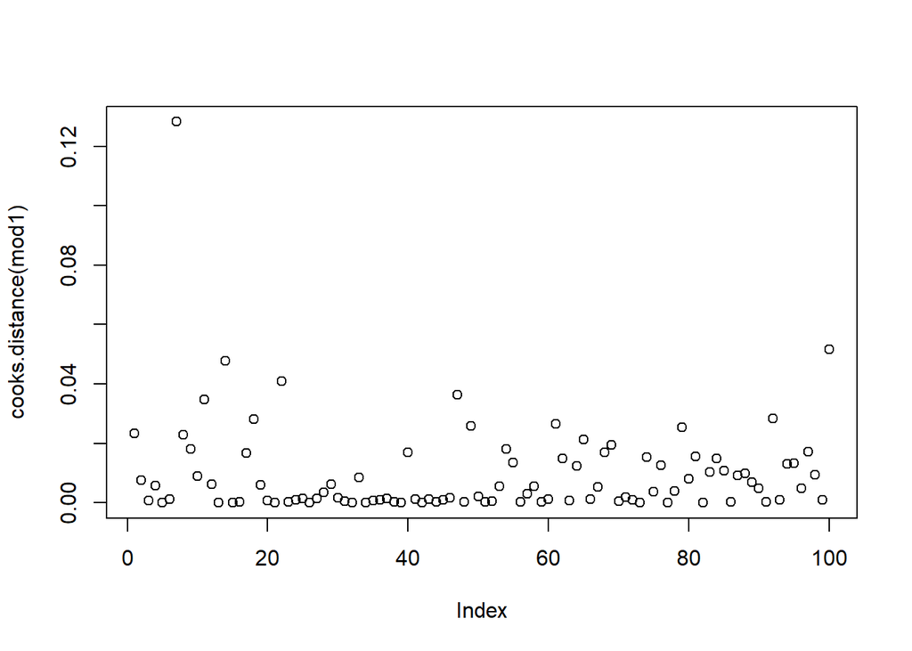

```r
plot(cooks.distance(mod1))
```

```r
which(cooks.distance(mod1) > 0.1)
```

```
## 7
## 7
```

```r
hatvalues(mod1)
```

```
##          1          2          3          4          5          6          7
## 0.08102361 0.07759012 0.08643509 0.08174711 0.14000028 0.07582374 0.09721698
##          8          9         10         11         12         13         14
## 0.07628926 0.07439691 0.04662431 0.05279359 0.04423439 0.04806288 0.06080497
##         15         16         17         18         19         20         21
## 0.10052423 0.07462282 0.08284870 0.06404132 0.06958332 0.10052423 0.04008247
##         22         23         24         25         26         27         28
## 0.36747172 0.09417109 0.04004388 0.05958272 0.04497897 0.04203221 0.06823631
##         29         30         31         32         33         34         35
## 0.08677528 0.06240874 0.03778341 0.08094839 0.06735789 0.04564838 0.07605345
##         36         37         38         39         40         41         42
## 0.03928903 0.07771845 0.04060177 0.11316219 0.04865353 0.03926800 0.13405924
##         43         44         45         46         47         48         49
## 0.08200940 0.05867554 0.07737790 0.08550600 0.15236362 0.07213961 0.08636882
##         50         51         52         53         54         55         56
## 0.10119922 0.07425766 0.09552807 0.07982462 0.04276906 0.36553020 0.04112957
##         57         58         59         60         61         62         63
## 0.11593633 0.06318673 0.05391594 0.08083116 0.14132134 0.06856870 0.04355736
##         64         65         66         67         68         69         70
## 0.07995531 0.12801050 0.03129822 0.05425808 0.06984566 0.05926831 0.06108122
##         71         72         73         74         75         76         77
## 0.09378108 0.11197005 0.06946865 0.06417551 0.07536757 0.05975082 0.06906446
##         78         79         80         81         82         83         84
## 0.08598108 0.13402726 0.03292832 0.05992802 0.15260195 0.07906456 0.03389825
##         85         86         87         88         89         90         91
## 0.04046887 0.04528527 0.04387797 0.03441900 0.07071769 0.05908952 0.04800643
##         92         93         94         95         96         97         98
## 0.06899995 0.15472827 0.06461389 0.08465701 0.17876725 0.09278016 0.06040246
##         99        100
## 0.06642955 0.05752006
```

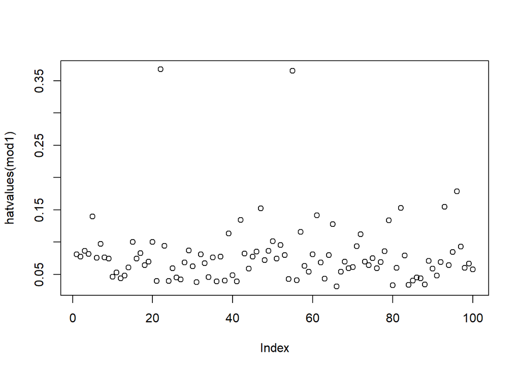

```r
plot(hatvalues(mod1))
```

```r
indices <- which(hatvalues(mod1) > 0.25)
hatco[indices, ]
```

```
##    empresa  tamano        adquisic         tindustr    tsitcomp velocidad
## 22      22 pequeña descentralizada otras industrias nueva tarea       3.4
## 55      55 pequeña descentralizada otras industrias nueva tarea       3.8
##    precio flexprec imgfabri servconj imgfvent calidadp fidelidad nfidelidad
## 22    0.4      8.3      2.5      1.2      1.7      5.2        35      medio
## 55    0.8      8.7      2.9      1.6      2.1      5.6        39      medio
##    nsatisfac
## 22      bajo
## 55      bajo
```

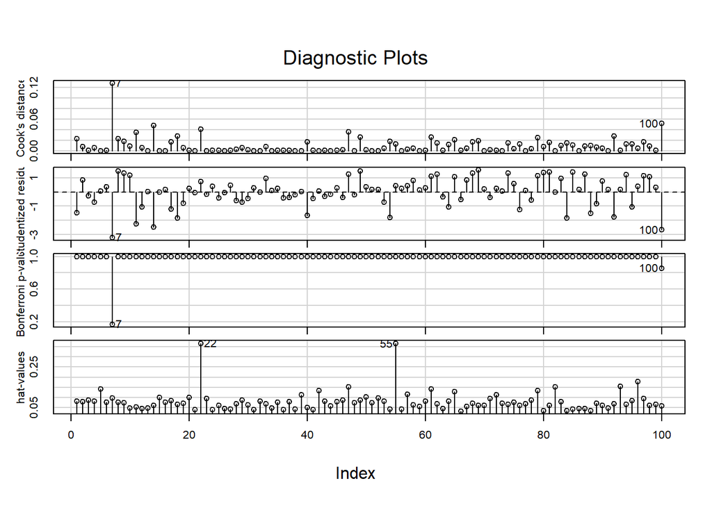

```r
influenceIndexPlot(mod1)
```

### 1.6.2 Eliminación observaciones anómalas

```r
hatco <- hatco[-c(7, 100), ]
mod2 <- lm(fidelidad ~ velocidad + precio + flexprec + imgfabri + servconj + imgfvent + calidadp, hatco)
mod2
```

```
##
## Call:
## lm(formula = fidelidad ~ velocidad + precio + flexprec + imgfabri +
##     servconj + imgfvent + calidadp, data = hatco)
##
## Coefficients:
## (Intercept)    velocidad       precio     flexprec     imgfabri     servconj
##    -12.0147      -0.5380      -1.0192       3.6122      -0.3987       9.0436
##    imgfvent     calidadp
##      2.2536       0.5584
```

```r
summary(mod2)
```

```
##
## Call:
## lm(formula = fidelidad ~ velocidad + precio + flexprec + imgfabri +
##     servconj + imgfvent + calidadp, data = hatco)
##
## Residuals:
##      Min       1Q   Median       3Q      Max
## -11.7561  -2.0858   0.4644   2.5387   6.7551
##
## Coefficients:
##             Estimate Std. Error t value Pr(>|t|)
## (Intercept) -12.0147     4.6055  -2.609   0.0106 *
## velocidad    -0.5380     1.8498  -0.291   0.7718
## precio       -1.0192     1.9153  -0.532   0.5959
## flexprec      3.6122     0.3799   9.508 3.01e-15 ***
## imgfabri     -0.3987     0.6146  -0.649   0.5182
## servconj      9.0436     3.5903   2.519   0.0135 *
## imgfvent      2.2536     0.8933   2.523   0.0134 *
## calidadp      0.5584     0.3265   1.710   0.0907 .
## ---
## Signif. codes:  0 '***' 0.001 '**' 0.01 '*' 0.05 '.' 0.1 ' ' 1
##
## Residual standard error: 4.043 on 90 degrees of freedom
## Multiple R-squared:  0.8121, Adjusted R-squared:  0.7975
## F-statistic: 55.56 on 7 and 90 DF,  p-value: < 2.2e-16
```

```r
anova(mod2)
```

```
## Analysis of Variance Table
##
## Response: fidelidad
##           Df Sum Sq Mean Sq  F value    Pr(>F)
## velocidad  1 3585.3  3585.3 219.3821 < 2.2e-16 ***
## precio     1  904.2   904.2  55.3305 5.765e-11 ***
## flexprec   1 1489.3  1489.3  91.1306 2.509e-15 ***
## imgfabri   1  131.7   131.7   8.0585  0.005598 **
## servconj   1   80.7    80.7   4.9381  0.028777 *
## imgfvent   1  116.9   116.9   7.1510  0.008898 **
## calidadp   1   47.8    47.8   2.9245  0.090690 .
## Residuals 90 1470.8    16.3
## ---
## Signif. codes:  0 '***' 0.001 '**' 0.01 '*' 0.05 '.' 0.1 ' ' 1
```

Observamos, si comparamos con el sumario y anova del mod1, que ka regresión se ajusta mejor, puesto que los p-valores son aún más reducidos en varias de las variables: eliminar los datos anómalos hace que nos ajustemos mejor al modelo Tampoco es una sorpresa, claro, precisamente hemos eliminado los datos que en cualquier caso son los que argumentan que el modelo es algo dudoso o no bien ajustado

### 1.6.3 Multicolinearidad

```r
R <- cor(hatco[, 6:12])
ai <- eigen(R)$values
sqrt(max(ai) / min(ai))
```

```
## [1] 16.67168
```

VIF:

```r
vif(mod2)
```

```
## velocidad    precio  flexprec  imgfabri  servconj  imgfvent  calidadp
## 35.695288 31.696869  1.646636  2.884906 43.396533  2.700327  1.614434
```

velocidad, precio y servconj tienen todos un vif > 30

### 1.6.4 Selección de variables explicativas

```r
step(mod2)
```

```
## Start:  AIC=281.44
## fidelidad ~ velocidad + precio + flexprec + imgfabri + servconj +
##     imgfvent + calidadp
##
##             Df Sum of Sq    RSS    AIC
## - velocidad  1      1.38 1472.2 279.54
## - precio     1      4.63 1475.5 279.75
## - imgfabri   1      6.88 1477.7 279.90
## <none>                   1470.8 281.44
## - calidadp   1     47.79 1518.6 282.58
## - servconj   1    103.69 1574.5 286.12
## - imgfvent   1    104.01 1574.8 286.14
## - flexprec   1   1477.38 2948.2 347.59
##
## Step:  AIC=279.54
## fidelidad ~ precio + flexprec + imgfabri + servconj + imgfvent +
##     calidadp
##
##            Df Sum of Sq    RSS    AIC
## - imgfabri  1      6.11 1478.3 277.94
## - precio    1     12.43 1484.6 278.36
## <none>                  1472.2 279.54
## - calidadp  1     47.69 1519.9 280.66
## - imgfvent  1    102.87 1575.1 284.16
## - flexprec  1   1478.35 2950.6 345.67
## - servconj  1   1805.21 3277.4 355.96
##
## Step:  AIC=277.94
## fidelidad ~ precio + flexprec + servconj + imgfvent + calidadp
##
##            Df Sum of Sq    RSS    AIC
## - precio    1     13.05 1491.4 276.80
## <none>                  1478.3 277.94
## - calidadp  1     46.45 1524.8 278.97
## - imgfvent  1    165.64 1644.0 286.35
## - flexprec  1   1500.56 2978.9 344.60
## - servconj  1   1807.08 3285.4 354.20
##
## Step:  AIC=276.8
## fidelidad ~ flexprec + servconj + imgfvent + calidadp
##
##            Df Sum of Sq    RSS    AIC
## <none>                  1491.4 276.80
## - calidadp  1     33.89 1525.3 277.01
## - imgfvent  1    169.54 1660.9 285.35
## - flexprec  1   2126.24 3617.6 361.64
## - servconj  1   2893.83 4385.2 380.50
```

```
##
## Call:
## lm(formula = fidelidad ~ flexprec + servconj + imgfvent + calidadp,
##     data = hatco)
##
## Coefficients:
## (Intercept)     flexprec     servconj     imgfvent     calidadp
##    -13.3173       3.7927       7.5142       1.8377       0.4223
```

```r
step(mod2, direction = "both")
```

```
## Start:  AIC=281.44
## fidelidad ~ velocidad + precio + flexprec + imgfabri + servconj +
##     imgfvent + calidadp
##
##             Df Sum of Sq    RSS    AIC
## - velocidad  1      1.38 1472.2 279.54
## - precio     1      4.63 1475.5 279.75
## - imgfabri   1      6.88 1477.7 279.90
## <none>                   1470.8 281.44
## - calidadp   1     47.79 1518.6 282.58
## - servconj   1    103.69 1574.5 286.12
## - imgfvent   1    104.01 1574.8 286.14
## - flexprec   1   1477.38 2948.2 347.59
##
## Step:  AIC=279.54
## fidelidad ~ precio + flexprec + imgfabri + servconj + imgfvent +
##     calidadp
##
##             Df Sum of Sq    RSS    AIC
## - imgfabri   1      6.11 1478.3 277.94
## - precio     1     12.43 1484.6 278.36
## <none>                   1472.2 279.54
## - calidadp   1     47.69 1519.9 280.66
## + velocidad  1      1.38 1470.8 281.44
## - imgfvent   1    102.87 1575.1 284.16
## - flexprec   1   1478.35 2950.6 345.67
## - servconj   1   1805.21 3277.4 355.96
##
## Step:  AIC=277.94
## fidelidad ~ precio + flexprec + servconj + imgfvent + calidadp
##
##             Df Sum of Sq    RSS    AIC
## - precio     1     13.05 1491.4 276.80
## <none>                   1478.3 277.94
## - calidadp   1     46.45 1524.8 278.97
## + imgfabri   1      6.11 1472.2 279.54
## + velocidad  1      0.61 1477.7 279.90
## - imgfvent   1    165.64 1644.0 286.35
## - flexprec   1   1500.56 2978.9 344.60
## - servconj   1   1807.08 3285.4 354.20
##
## Step:  AIC=276.8
## fidelidad ~ flexprec + servconj + imgfvent + calidadp
##
##             Df Sum of Sq    RSS    AIC
## <none>                   1491.4 276.80
## - calidadp   1     33.89 1525.3 277.01
## + precio     1     13.05 1478.3 277.94
## + velocidad  1     10.39 1481.0 278.12
## + imgfabri   1      6.73 1484.6 278.36
## - imgfvent   1    169.54 1660.9 285.35
## - flexprec   1   2126.24 3617.6 361.64
## - servconj   1   2893.83 4385.2 380.50
```

```
##
## Call:
## lm(formula = fidelidad ~ flexprec + servconj + imgfvent + calidadp,
##     data = hatco)
##
## Coefficients:
## (Intercept)     flexprec     servconj     imgfvent     calidadp
##    -13.3173       3.7927       7.5142       1.8377       0.4223
```